# 608: hw1

Jie Zou

2022-02-13

**Principles of Data Visualization and Introduction to ggplot2**

I have provided you with data about the 5,000 fastest growing companies in the US, as compiled by Inc. magazine. lets read this in:

```r
inc <- read.csv("https://raw.githubusercontent.com/charleyferrari/CUNY_DATA_608/master/module1/Data/inc5000_data.csv", header= TRUE)
```

And lets preview this data:

```r
head(inc)
```

```
##   Rank                         Name Growth_Rate   Revenue
## 1    1                         Fuhu      421.48 1.179e+08
## 2    2        FederalConference.com      248.31 4.960e+07
## 3    3                The HCI Group      245.45 2.550e+07
## 4    4                      Bridger      233.08 1.900e+09
## 5    5                       DataXu      213.37 8.700e+07
## 6    6 MileStone Community Builders      179.38 4.570e+07
##                       Industry Employees         City State
## 1 Consumer Products & Services       104   El Segundo    CA
## 2          Government Services        51     Dumfries    VA
## 3                       Health       132 Jacksonville    FL
## 4                       Energy        50      Addison    TX
## 5      Advertising & Marketing       220       Boston    MA
## 6                  Real Estate        63       Austin    TX
```

```r
summary(inc)
```

```
##       Rank          Name            Growth_Rate         Revenue
##  Min.   :   1   Length:5001        Min.   :  0.340   Min.   :2.000e+06
##  1st Qu.:1252   Class :character   1st Qu.:  0.770   1st Qu.:5.100e+06
##  Median :2502   Mode  :character   Median :  1.420   Median :1.090e+07
##  Mean   :2502                      Mean   :  4.612   Mean   :4.822e+07
##  3rd Qu.:3751                      3rd Qu.:  3.290   3rd Qu.:2.860e+07
##  Max.   :5000                      Max.   :421.480   Max.   :1.010e+10
##
##    Industry           Employees           City              State
##  Length:5001        Min.   :    1.0   Length:5001        Length:5001
##  Class :character   1st Qu.:   25.0   Class :character   Class :character
##  Mode  :character   Median :   53.0   Mode  :character   Mode  :character
##                     Mean   :  232.7
##                     3rd Qu.:  132.0
##                     Max.   :66803.0
##                     NA's   :12
```

Think a bit on what these summaries mean. Use the space below to add some more relevant non-visual exploratory information you think helps you understand this data:

```r
library(dplyr)
library(tidyverse)
library(gghighlight)
```

not sure which year is the data being collected, I did a little research about the top rank company. If it is around 2013, according to Wikipedia, its growth rate makes sense.

```r
# from the summary, Growth_Rate seems to have outliers

inc[1:5,]
```

```
##   Rank                  Name Growth_Rate   Revenue                     Industry
## 1    1                  Fuhu      421.48 1.179e+08 Consumer Products & Services
## 2    2 FederalConference.com      248.31 4.960e+07          Government Services
## 3    3         The HCI Group      245.45 2.550e+07                       Health
## 4    4               Bridger      233.08 1.900e+09                       Energy
## 5    5                DataXu      213.37 8.700e+07      Advertising & Marketing
##   Employees         City State
## 1       104   El Segundo    CA
## 2        51     Dumfries    VA
## 3       132 Jacksonville    FL
## 4        50      Addison    TX
## 5       220       Boston    MA
```

less than 1% of data present with NA, for the further analysis, I will decide to drop them.

```r
# from summary, Employees have missing value
data <- inc %>%
  filter(!is.na(Employees))
```

Total 25 different industries in which IT service take up the most, which is the most popular one

```r
# Among all state, which industry is the most popular?

data %>%
  select(Industry) %>%
  group_by(Industry) %>%
  count(sort = T)
```

```
## # A tibble: 25 × 2
## # Groups:   Industry [25]
##    Industry                         n
##    <chr>                        <int>
##  1 IT Services                    732
##  2 Business Products & Services   480
##  3 Advertising & Marketing        471
##  4 Health                         354
##  5 Software                       341
##  6 Financial Services             260
##  7 Manufacturing                  255
##  8 Consumer Products & Services   203
##  9 Retail                         203
## 10 Government Services            202
## # … with 15 more rows
```

based on extracted data, Business Products & Services has the highest revenue across states

```r
# which industry has the most annual revenue?

data %>%
  select(Industry, Revenue) %>%
  group_by(Industry) %>%
  summarize(total_revenue = sum(Revenue)) %>%
  arrange(desc(total_revenue))
```

```
## # A tibble: 25 × 2
##    Industry                     total_revenue
##    <chr>                                <dbl>
##  1 Business Products & Services   26345900000
##  2 IT Services                    20525000000
##  3 Health                         17860100000
##  4 Consumer Products & Services   14956400000
##  5 Logistics & Transportation     14837800000
##  6 Energy                         13771600000
##  7 Construction                   13174300000
##  8 Financial Services             13150900000
##  9 Food & Beverage                12812500000
## 10 Manufacturing                  12603600000
## # … with 15 more rows
```

## Question 1

Create a graph that shows the distribution of companies in the dataset by State (ie how many are in each state). There are a lot of States, so consider which axis you should use. This visualization is ultimately going to be consumed on a ‘portrait’ oriented screen (ie taller than wide), which should further guide your layout choices.

```r
# subset of data with only state and number of companies
states <- data %>%
  group_by(State) %>%
  select(Name, State) %>%
  count(Name) %>%
  summarize(num_comp = sum(n)) %>%
  arrange(desc(num_comp))

# first few row of data
head(states)
```

```
## # A tibble: 6 × 2
##   State num_comp
##   <chr>    <int>
## 1 CA         700
## 2 TX         386
## 3 NY         311
## 4 VA         283
## 5 FL         282
## 6 IL         272
```

```
## label_key: State
```

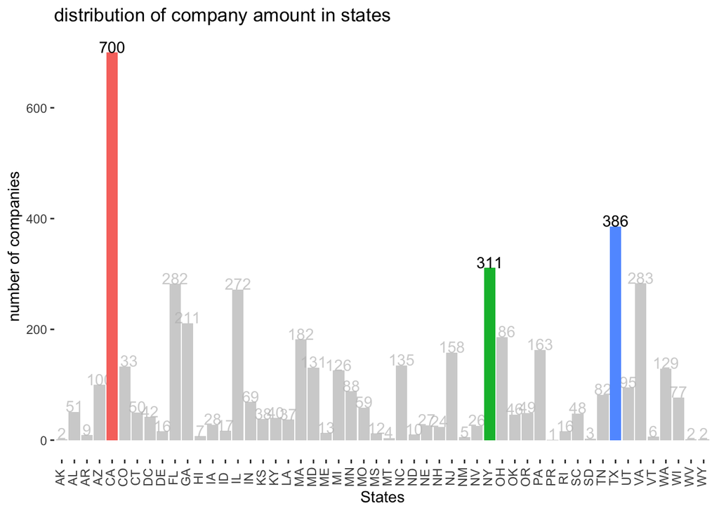

```r
# make barplot and highlight the top three
states %>%
  ggplot(aes(x = State, y = num_comp, fill = State)) +
  geom_bar(stat = 'identity') +
  geom_text(aes(label = num_comp), vjust = 0) +
  theme(panel.background = element_blank(),
        axis.text.x = element_text(angle = 90, vjust = 0.3, hjust = 0.3)) +
  gghighlight(State == 'CA' | State == 'TX' | State == 'NY') +
  labs(x = 'States',
       y = 'number of companies',
       title = 'distribution of company amount in states')
```

## Quesiton 2

Lets dig in on the state with the 3rd most companies in the data set. Imagine you work for the state and are interested in how many people are employed by companies in different industries. Create a plot that shows the average and/or median employment by industry for companies in this state (only use cases with full data, use R’s `complete.cases()` function.) In addition to this, your graph should show how variable the ranges are, and you should deal with outliers.

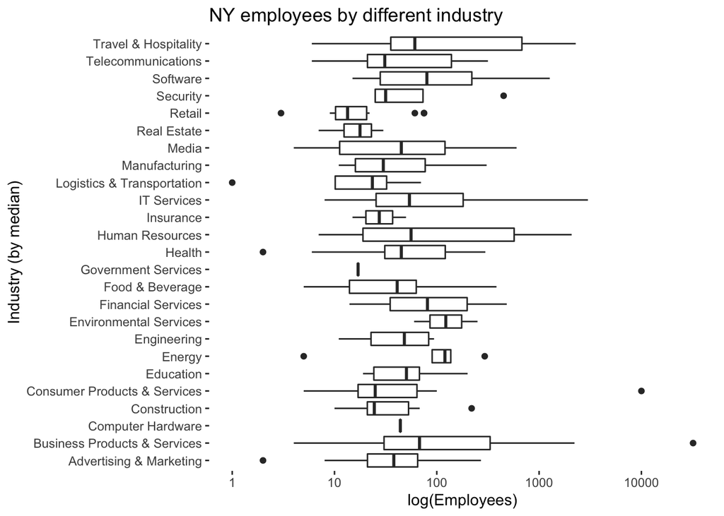

```r
# get the complete cases in NY state
ny <- data %>%
  filter(State == 'NY') %>%
  filter(complete.cases(.))

# make box plot to show median and range. scale to reduce extreme outliers
ny %>%
  select(Industry, Employees) %>%
  ggplot(aes(x = Industry, y = Employees)) +
  geom_boxplot() +
  scale_y_log10() +
  coord_flip() +
  theme(panel.background = element_blank()) +
  labs(x = 'Industry (by median)',
       y = 'log(Employees)',
       title = 'NY employees by different industry')
```

## Question 3

Now imagine you work for an investor and want to see which industries generate the most revenue per employee. Create a chart that makes this information clear. Once again, the distribution per industry should be shown.

```
## label_key: Industry
```

[figure not shown]

```r
# create data with industry and revenue per employees
inv <- ny %>%
  select(Industry, Employees, Revenue) %>%
  group_by(Industry) %>%
  summarize(rev_per_emp = sum(Revenue) / sum(Employees)) %>%
  arrange(desc(rev_per_emp))

# make barplot and highlight the top one.
inv %>%
  ggplot(aes(x = Industry, y = rev_per_emp, fill = Industry)) +
  geom_bar(stat = 'identity') +
  theme(panel.background = element_blank()) +
  coord_flip() +
  gghighlight(rev_per_emp == max(inv$rev_per_emp)) +
  labs(x = 'Industry in NY',
       y = 'revenue per employees',
       title = 'NY state industries generate revernue per employees')
```